# House Selling Prices

## Mutating the Data

```r
train <- read.csv("Data/train.csv", header = TRUE)
                  #, stringAsFactors = TRUE)

train <- train %>%
  mutate(
    MSZoning1 = case_when(
      MSZoning == 'C' ~ 1,
      MSZoning == 'FV' ~ 2,
      MSZoning == 'RH' ~ 3,
      MSZoning == 'RL' ~ 4,
      MSZoning == 'RM' ~ 5
    )
  )

train <- train %>%
  mutate(
    MSZoning2 = case_when(
      MSZoning1 == 4 ~ 0,
      MSZoning1 == c(1,2,3,5) ~ 1,
    )
  )

# figure out how to do find and replace in Excel

#train <- train %>%
#  mutate(
#    LotFrontageSw = case_when(
#      LotFrontage == 0 ~ 0,
#      LotFrontage != 0 ~ 1
#    )
#  )
```

The code that can be opened above shows that I created a couple switches based on categories in MSZoning that stood out. These will be used in the regression. My goal is to use a high-dimensional model to predict the trend of house prices.

## The Regression and Interpretation

Below is the HD model I put together. As you can see, all the variables are significant, and the adjusted R-squared is 0.797, indicating that this model is a good fit for the data.

```r
View(train)

#lm.1stflr <- lm(SalePrice ~ X1stFlrSF, data=train)
#summary(lm.1stflr)

#lm.alley <- lm(SalePrice ~ Alley, data=train)
#summary(lm.alley)

#lm.fence <- lm(SalePrice ~ Fence, data=train)
#summary(lm.fence)

#lm.1stflr <- lm(SalePrice ~ X1stFlrSF, data=train)
#summary(lm.1stflr)

#lm.2ndflr <- lm(SalePrice ~ X2ndFlrSF, data=train)
#summary(lm.2ndflr)

#lm.basement <- lm(SalePrice ~ TotalBsmtSF, data=train)
#summary(lm.basement)

total.lm <- lm(SalePrice ~ X1stFlrSF + X2ndFlrSF + OverallQual + YearRemodAdd + MasVnrArea + BsmtQual + BsmtFinSF1 + BsmtFinSF2 + GarageArea + MSZoning2 + MSZoning1, data = train)
pander(summary(total.lm))
```

|  | Estimate | Std. Error | t value | Pr(>\|t\|) |
| --- | --- | --- | --- | --- |
| **(Intercept)** | -643688 | 137170 | -4.693 | 3.007e-06 |
| **X1stFlrSF** | 55.27 | 3.903 | 14.16 | 3.211e-42 |
| **X2ndFlrSF** | 47.65 | 2.79 | 17.08 | 9.983e-59 |
| **OverallQual** | 18979 | 1326 | 14.31 | 5.242e-43 |
| **YearRemodAdd** | 340.1 | 68.93 | 4.934 | 9.182e-07 |
| **MasVnrArea** | 31.96 | 6.658 | 4.8 | 1.79e-06 |
| **BsmtQualFa** | -53092 | 9807 | -5.413 | 7.457e-08 |
| **BsmtQualGd** | -45011 | 4273 | -10.53 | 7.041e-25 |
| **BsmtQualNoBa** | -55336 | 8631 | -6.412 | 2.065e-10 |
| **BsmtQualTA** | -51735 | 5176 | -9.995 | 1.193e-22 |
| **BsmtFinSF1** | 17.69 | 2.573 | 6.874 | 9.977e-12 |
| **BsmtFinSF2** | 14.42 | 6.255 | 2.306 | 0.02129 |
| **GarageArea** | 30.76 | 6.648 | 4.627 | 4.11e-06 |
| **MSZoning2** | -16224 | 4492 | -3.612 | 0.0003167 |
| **MSZoning1** | -6338 | 3165 | -2.003 | 0.04541 |

Fitting linear model: SalePrice ~ X1stFlrSF + X2ndFlrSF + OverallQual + YearRemodAdd + MasVnrArea + BsmtQual + BsmtFinSF1 + BsmtFinSF2 + GarageArea + MSZoning2 + MSZoning1

| Observations | Residual Std. Error | $R^2$ | Adjusted $R^2$ |
| --- | --- | --- | --- |
| 1217 | 36100 | 0.7993 | 0.797 |

```r
#Put them all together into a high dimensional multiple regression model

#lm.sqft.all <- lm(SalePrice ~ X1stFlrSF + X2ndFlrSF + TotalBsmtSF, data=train)
#summary(lm.sqft.all)

#Or use mutate and create a new "TotalSF" variable that allows for a simple linear regression model that is just as powerful, but far easier to graph and interpret.

#train <- train %>%
#  mutate(TotalSF = X1stFlrSF + X2ndFlrSF + TotalBsmtSF)

#lm.sqft <- lm(SalePrice ~ TotalSF, data=train)
#summary(lm.sqft)

#ggplot(train, aes(x = X1stFlrSF, y = SalePrice, col = as.factor(MSZoning))) +
#  geom_point(pch = 1) +
#  scale_color_manual(values = c('red', 'blue', 'purple', 'green', 'orange'))



#plot(SalePrice ~ MSZoning1, data = train)
#abline(lm.sqft)
#plot(lm.sqft, which = 1)
#plot(lm.sqft$res ~ ., data = train)

#Notice as well how mutate can be used to change complicated variables into simple on-off switches.

#train <- train %>%
#  mutate(TotalSF = X1stFlrSF + X2ndFlrSF + TotalBsmtSF,
#                RichNbrhd = case_when(Neighborhood %in% c("StoneBr", "NridgHt", "NoRidge") ~ 1,
#                                                          TRUE ~ 0))

#lm.sqft.rich <- lm(SalePrice ~ TotalSF + RichNbrhd + TotalSF:RichNbrhd, data=train)
#summary(lm.sqft.rich)
```

*(intercept):* For homes with no square footage, the predicted price is -643,700 dollars.

*X1stFlrSF:* For every square foot increase in first floor surface area, the predicted price of the home goes up by 55.27 dollars.

*X2ndFlrSF:* For every square foot increase in second floor surface area, the predicted price of the home goes up by 47.65 dollars.

*OverallQual:* For every increment increase in overall material and finish of the house (on a ten-point scale), the predicted price of the home goes up by 18,980 dollars.

*YearRemodAdd:* For every year increase in date of remodel (or construction if not remodeled), the predicted price of the home goes up by 340.10 dollars.

*MasVnrArea:* For every square foot increase in the area of the masonry veneer, the average value of the home goes up by 31.96 dollars.

*BsmtQualFa:* For a basement height of 70-79 inches, the average value of the home goes down by 53,090 dollars from the price of a home with a basement height of over 100 inches.

*BsmtQualGd:* For a basement height of 90-99 inches, the average value of the home goes down by 45,010 dollars from the price of a home with a basement height of over 100 inches.

*BsmtQualNo Basement:* For a home without a basement, the average value of it goes down by 55,340 dollars from the price of a home with a basement height over 100 inches.

*BsmtQualTA:* For a basement height of 80-89 inches, the average value of the home goes down by 51,740 dollars from the price of a home with a basement height of over 100 inches.

*BsmtFinSF1:* For every square foot increase in the area of the type 1 basement finish, the average price of the home increased by 17.69 dollars.

*BsmtFinSF2:* For every square foot increase in the area of the type 2 basement finish, the average price of the home increased by 14.42 dollars.

*GarageArea:* For every square foot increase in the garage area, the predicted price of the home went up by 30.76 dollars.

## Visualization

I visualized the model with a combination of 2D graphs for every variable I included. I also colored them by the BsmtQual factor, so I could see the relationship it has with each variable, which is usually well-defined.

The plot below shows a positive trend between sale price and square footage of the home’s first floor.

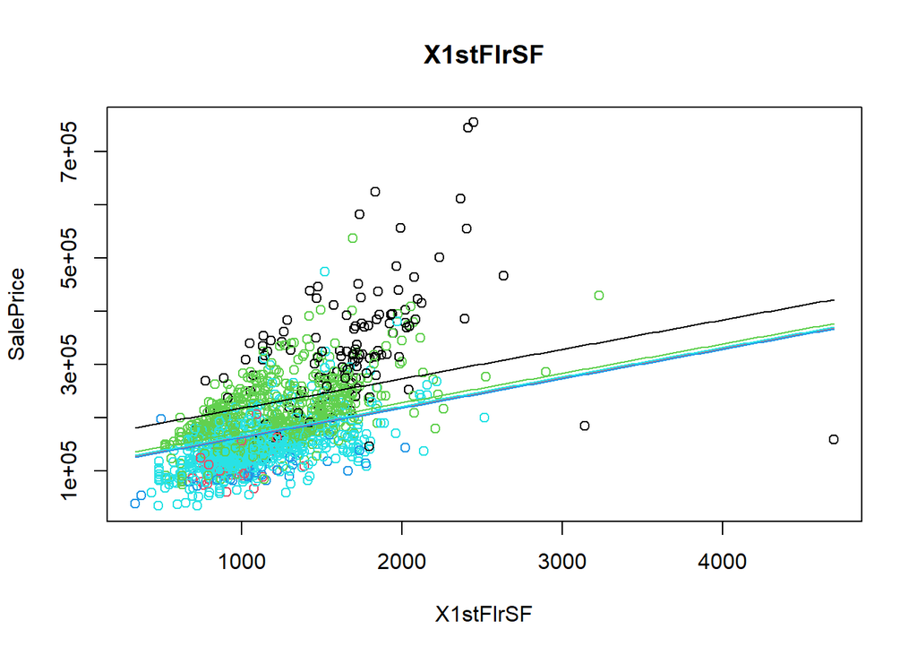

```r
train <- train %>%
  mutate(
    Fa = case_when(
      BsmtQual == 'Fa' ~ 1,
      BsmtQual != 'Fa' ~ 0
    ))
train <- train %>%
  mutate(
    Gd = case_when(
      BsmtQual == 'Gd' ~ 1,
      BsmtQual != 'Gd' ~ 0
    ))
train <- train %>%
  mutate(
    NoBa = case_when(
      BsmtQual == 'NoBa' ~ 1,
      BsmtQual != 'NoBa' ~ 0
    ))
train <- train %>%
  mutate(
    TA = case_when(
      BsmtQual == 'TA' ~ 1,
      BsmtQual != 'TA' ~ 0
    ))

plot(SalePrice ~ X1stFlrSF, data = train, col = as.factor(BsmtQual), main = 'X1stFlrSF')
b <- coef(total.lm)

drawit <- function(Fa = 0, Gd = 0, NoBa = 0, TA = 0, i){
  curve(b[1] + b[2]*X1stFlrSF + b[3]*mean(train$X2ndFlrSF) + b[4]*mean(train$OverallQual) + b[5]*mean(train$YearRemodAdd) + b[6]*mean(train$MasVnrArea, na.rm = TRUE) + b[7]*Fa + b[8]*Gd + b[9]*NoBa + b[10]*TA + b[11]*mean(train$BsmtFinSF1) + b[12]*mean(train$BsmtFinSF2) + b[13]*mean(train$GarageArea) + b[14]*mean(train$MSZoning2, na.rm = TRUE) + b[15]*mean(train$MSZoning1, na.rm = TRUE), add = TRUE, xname = 'X1stFlrSF', col = palette()[i])
}

drawit(0,0,0,0,1)
drawit(1,0,0,0,2)
drawit(0,1,0,0,3)
drawit(0,0,1,0,4)
drawit(0,0,0,1,5)
```

The plot below shows a positive trend between sale price and square footage of the home’s second floor, given that the home has a second floor.

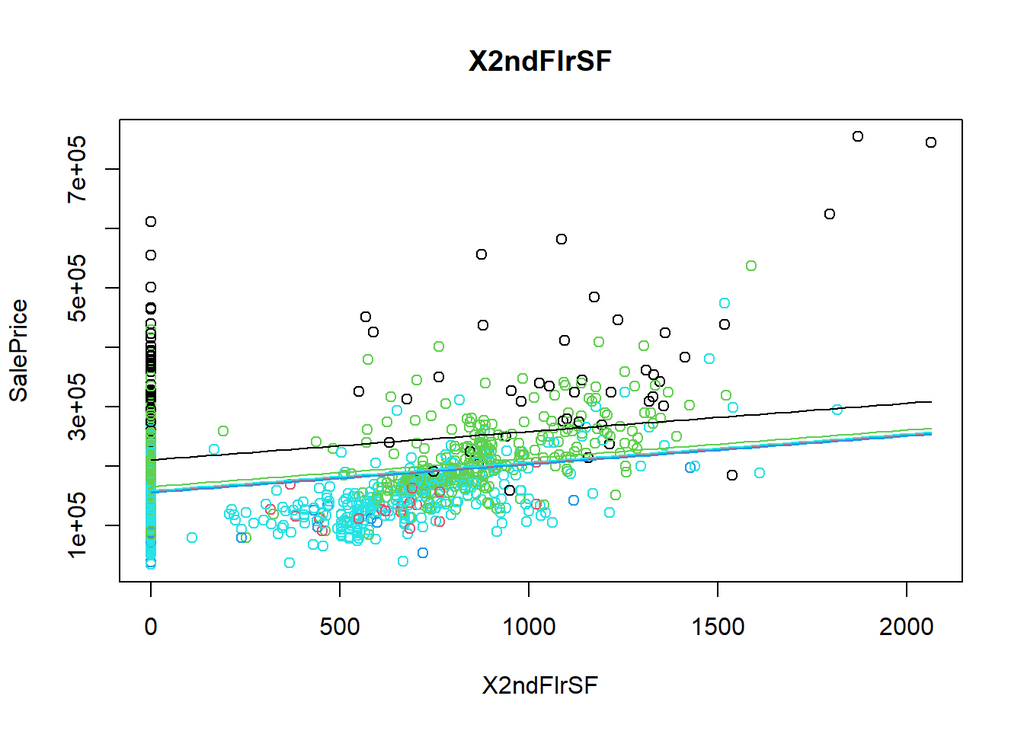

```r
plot(SalePrice ~ X2ndFlrSF, data = train, col = as.factor(BsmtQual), main = 'X2ndFlrSF')

drawit <- function(Fa = 0, Gd = 0, NoBa = 0, TA = 0, i){
  curve(b[1] + b[2]*mean(train$X1stFlrSF) + b[3]*X2ndFlrSF + b[4]*mean(train$OverallQual) + b[5]*mean(train$YearRemodAdd) + b[6]*mean(train$MasVnrArea, na.rm = TRUE) + b[7]*Fa + b[8]*Gd + b[9]*NoBa + b[10]*TA + b[11]*mean(train$BsmtFinSF1) + b[12]*mean(train$BsmtFinSF2) + b[13]*mean(train$GarageArea) + b[14]*mean(train$MSZoning2, na.rm = TRUE) + b[15]*mean(train$MSZoning1, na.rm = TRUE), add = TRUE, xname = 'X2ndFlrSF', col = palette()[i])
}

drawit(0,0,0,0,1)
drawit(1,0,0,0,2)
drawit(0,1,0,0,3)
drawit(0,0,1,0,4)
drawit(0,0,0,1,5)
```

The plot below shows a strong positive trend between sale price and overall quality (on a scale of 1 to 10).

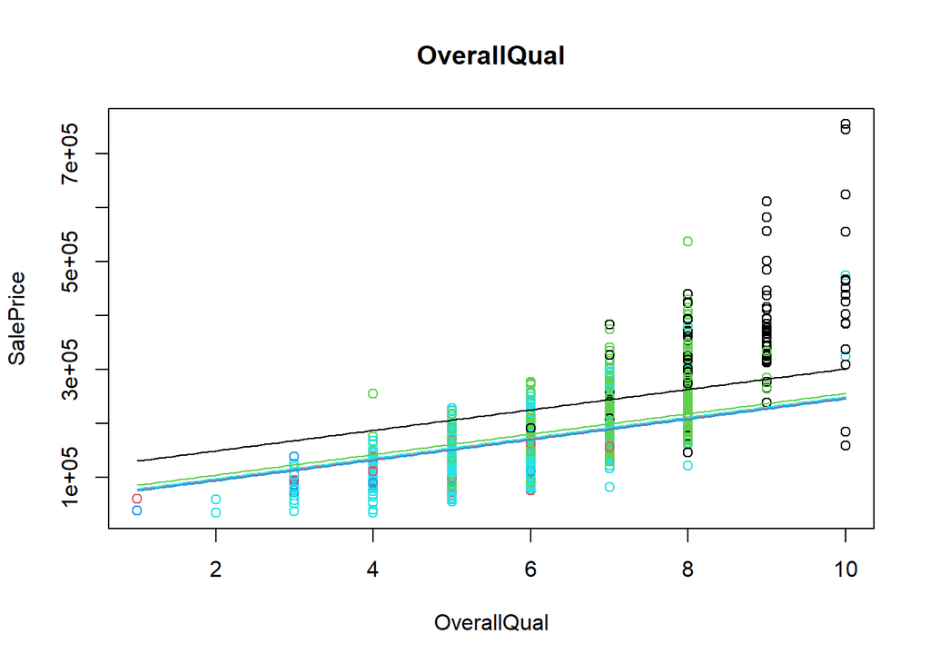

```r
plot(SalePrice ~ OverallQual, data = train, col = as.factor(BsmtQual), main = 'OverallQual')

drawit <- function(Fa = 0, Gd = 0, NoBa = 0, TA = 0, i){
  curve(b[1] + b[2]*mean(train$X1stFlrSF) + b[3]*mean(train$X2ndFlrSF) + b[4]*OverallQual + b[5]*mean(train$YearRemodAdd) + b[6]*mean(train$MasVnrArea, na.rm = TRUE) + b[7]*Fa + b[8]*Gd + b[9]*NoBa + b[10]*TA + b[11]*mean(train$BsmtFinSF1) + b[12]*mean(train$BsmtFinSF2) + b[13]*mean(train$GarageArea) + b[14]*mean(train$MSZoning2, na.rm = TRUE) + b[15]*mean(train$MSZoning1, na.rm = TRUE), add = TRUE, xname = 'OverallQual', col = palette()[i])
}

drawit(0,0,0,0,1)
drawit(1,0,0,0,2)
drawit(0,1,0,0,3)
drawit(0,0,1,0,4)
drawit(0,0,0,1,5)
```

This plot below shows a general upward trend between year last remodeled (or year built if not remodeled). This trend could be clearer with a transformation.

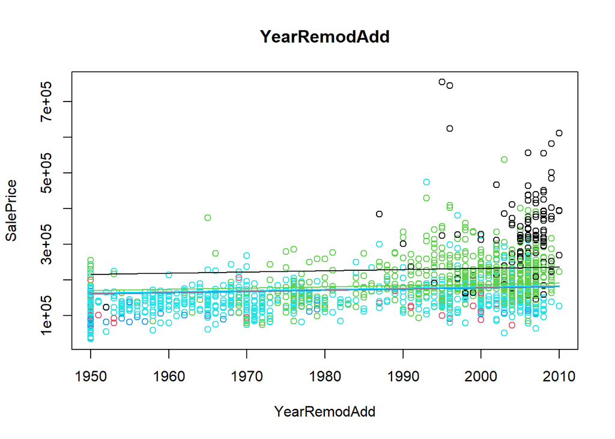

```r
plot(SalePrice ~ YearRemodAdd, data = train, col = as.factor(BsmtQual), main = 'YearRemodAdd')

drawit <- function(Fa = 0, Gd = 0, NoBa = 0, TA = 0, i){
  curve(b[1] + b[2]*mean(train$X1stFlrSF) + b[3]*mean(train$X2ndFlrSF) + b[4]*mean(train$OverallQual) + b[5]*YearRemodAdd + b[6]*mean(train$MasVnrArea, na.rm = TRUE) + b[7]*Fa + b[8]*Gd + b[9]*NoBa + b[10]*TA + b[11]*mean(train$BsmtFinSF1) + b[12]*mean(train$BsmtFinSF2) + b[13]*mean(train$GarageArea) + b[14]*mean(train$MSZoning2, na.rm = TRUE) + b[15]*mean(train$MSZoning1, na.rm = TRUE), add = TRUE, xname = 'YearRemodAdd', col = palette()[i])
}

drawit(0,0,0,0,1)
drawit(1,0,0,0,2)
drawit(0,1,0,0,3)
drawit(0,0,1,0,4)
drawit(0,0,0,1,5)
```

The plot below shows a positive trend between sale price and masonry veneer area (in square feet).

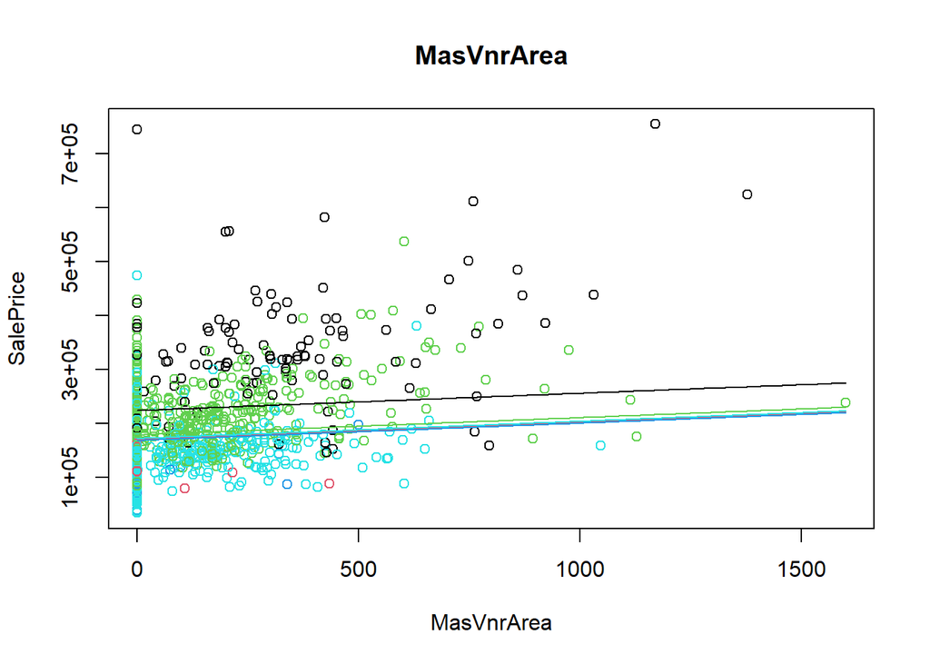

```r
plot(SalePrice ~ MasVnrArea, data = train, col = as.factor(BsmtQual), main = 'MasVnrArea')

drawit <- function(Fa = 0, Gd = 0, NoBa = 0, TA = 0, i){
  curve(b[1] + b[2]*mean(train$X1stFlrSF) + b[3]*mean(train$X2ndFlrSF) + b[4]*mean(train$OverallQual) + b[5]*mean(train$YearRemodAdd) + b[6]*MasVnrArea + b[7]*Fa + b[8]*Gd + b[9]*NoBa + b[10]*TA + b[11]*mean(train$BsmtFinSF1) + b[12]*mean(train$BsmtFinSF2) + b[13]*mean(train$GarageArea) + b[14]*mean(train$MSZoning2, na.rm = TRUE) + b[15]*mean(train$MSZoning1, na.rm = TRUE), add = TRUE, xname = 'MasVnrArea', col = palette()[i])
}

drawit(0,0,0,0,1)
drawit(1,0,0,0,2)
drawit(0,1,0,0,3)
drawit(0,0,1,0,4)
drawit(0,0,0,1,5)
```

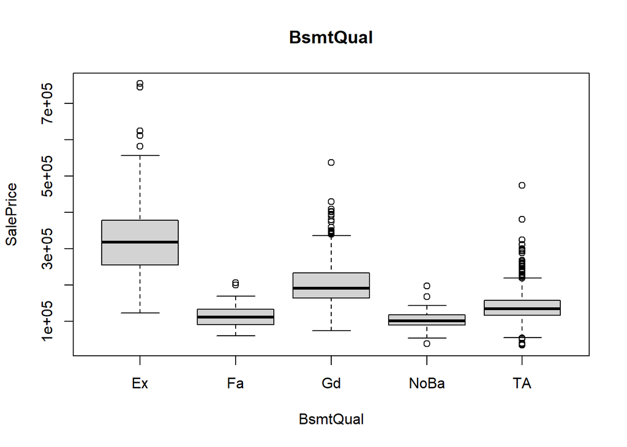

```r
boxplot(SalePrice ~ BsmtQual, data = train, main = 'BsmtQual')
```

This plot below shows an upward trend with a high slope between sale price and the square footage of the first type of basement finish. If the homes without this particular basement finish were taken out, I think we would have stronger significance and a more obvious trend.

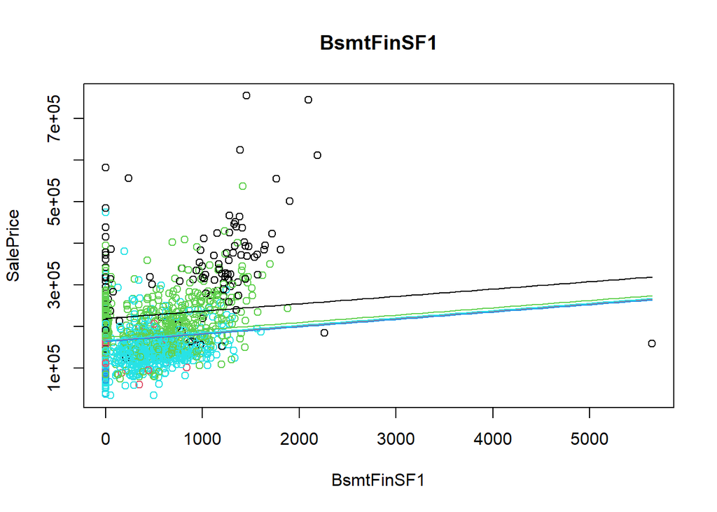

```r
plot(SalePrice ~ BsmtFinSF1, data = train, col = as.factor(BsmtQual), main = 'BsmtFinSF1')

drawit <- function(Fa = 0, Gd = 0, NoBa = 0, TA = 0, i){
  curve(b[1] + b[2]*mean(train$X1stFlrSF) + b[3]*mean(train$X2ndFlrSF) + b[4]*mean(train$OverallQual) + b[5]*mean(train$YearRemodAdd) + b[6]*mean(train$MasVnrArea, na.rm = TRUE) + b[7]*Fa + b[8]*Gd + b[9]*NoBa + b[10]*TA + b[11]*BsmtFinSF1 + b[12]*mean(train$BsmtFinSF2) + b[13]*mean(train$GarageArea) + b[14]*mean(train$MSZoning2, na.rm = TRUE) + b[15]*mean(train$MSZoning1, na.rm = TRUE), add = TRUE, xname = 'BsmtFinSF1', col = palette()[i])
}

drawit(0,0,0,0,1)
drawit(1,0,0,0,2)
drawit(0,1,0,0,3)
drawit(0,0,1,0,4)
drawit(0,0,0,1,5)
```

This plot below shows no particular trend, but it does show that the sale price drops drastically when homes do have this particular basement finish.

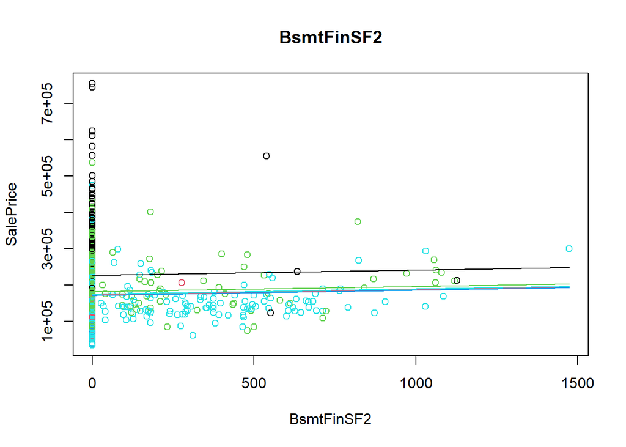

```r
plot(SalePrice ~ BsmtFinSF2, data = train, col = as.factor(BsmtQual), main = 'BsmtFinSF2')

drawit <- function(Fa = 0, Gd = 0, NoBa = 0, TA = 0, i){
  curve(b[1] + b[2]*mean(train$X1stFlrSF) + b[3]*mean(train$X2ndFlrSF) + b[4]*mean(train$OverallQual) + b[5]*mean(train$YearRemodAdd) + b[6]*mean(train$MasVnrArea, na.rm = TRUE) + b[7]*Fa + b[8]*Gd + b[9]*NoBa + b[10]*TA + b[11]*mean(train$BsmtFinSF1) + b[12]*BsmtFinSF2 + b[13]*mean(train$GarageArea) + b[14]*mean(train$MSZoning2, na.rm = TRUE) + b[15]*mean(train$MSZoning1, na.rm = TRUE), add = TRUE, xname = 'BsmtFinSF2', col = palette()[i])
}

drawit(0,0,0,0,1)
drawit(1,0,0,0,2)
drawit(0,1,0,0,3)
drawit(0,0,1,0,4)
drawit(0,0,0,1,5)
```

The plot below shows a strong positive trend between sale price and square footage of its garage. Even when the homes without garages are included, the trend is still strong.

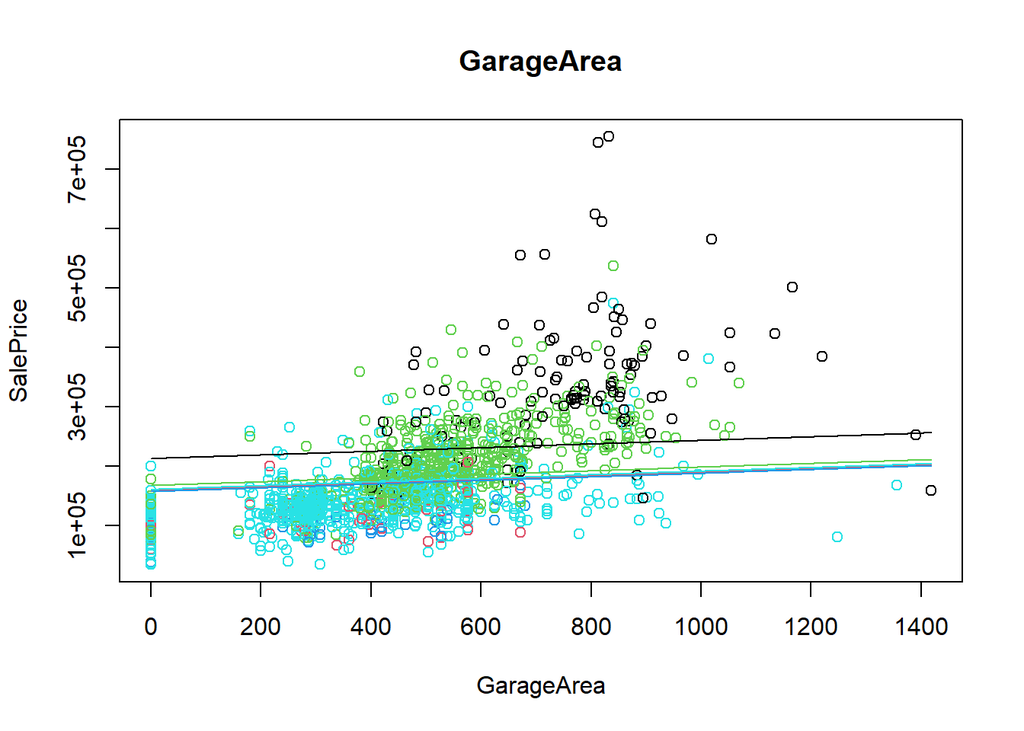

```r
plot(SalePrice ~ GarageArea, data = train, col = as.factor(BsmtQual), main = 'GarageArea')

drawit <- function(Fa = 0, Gd = 0, NoBa = 0, TA = 0, i){
  curve(b[1] + b[2]*mean(train$X1stFlrSF) + b[3]*mean(train$X2ndFlrSF) + b[4]*mean(train$OverallQual) + b[5]*mean(train$YearRemodAdd) + b[6]*mean(train$MasVnrArea, na.rm = TRUE) + b[7]*Fa + b[8]*Gd + b[9]*NoBa + b[10]*TA + b[11]*mean(train$BsmtFinSF1) + b[12]*mean(train$BsmtFinSF2) + b[13]*GarageArea + b[14]*mean(train$MSZoning2, na.rm = TRUE) + b[15]*mean(train$MSZoning1, na.rm = TRUE), add = TRUE, xname = 'GarageArea', col = palette()[i])
}

drawit(0,0,0,0,1)
drawit(1,0,0,0,2)
drawit(0,1,0,0,3)
drawit(0,0,1,0,4)
drawit(0,0,0,1,5)
```

This plot below shows that residential low density (0) housing tends to have a greater sale price than any other kind of market category (1).

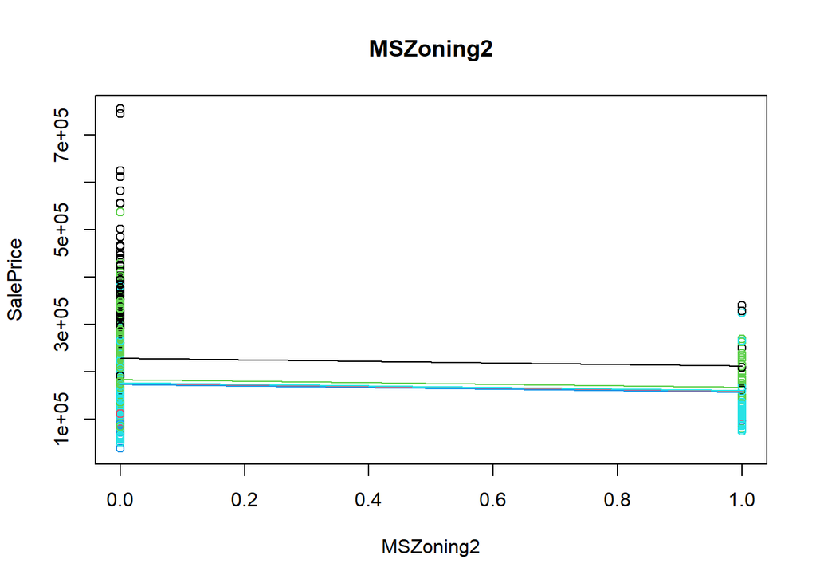

```r
plot(SalePrice ~ MSZoning2, data = train, col = as.factor(BsmtQual), main = 'MSZoning2')

drawit <- function(Fa = 0, Gd = 0, NoBa = 0, TA = 0, i){
  curve(b[1] + b[2]*mean(train$X1stFlrSF) + b[3]*mean(train$X2ndFlrSF) + b[4]*mean(train$OverallQual) + b[5]*mean(train$YearRemodAdd) + b[6]*mean(train$MasVnrArea, na.rm = TRUE) + b[7]*Fa + b[8]*Gd + b[9]*NoBa + b[10]*TA + b[11]*mean(train$BsmtFinSF1) + b[12]*mean(train$BsmtFinSF2) + b[13]*mean(train$GarageArea) + b[14]*MSZoning2 + b[15]*mean(train$MSZoning1, na.rm = TRUE), add = TRUE, xname = 'MSZoning2', col = palette()[i])
}

drawit(0,0,0,0,1)
drawit(1,0,0,0,2)
drawit(0,1,0,0,3)
drawit(0,0,1,0,4)
drawit(0,0,0,1,5)
```

This plot also supports the claim above that residential low density housing (4) has a greater sale price than the other categories of housing.

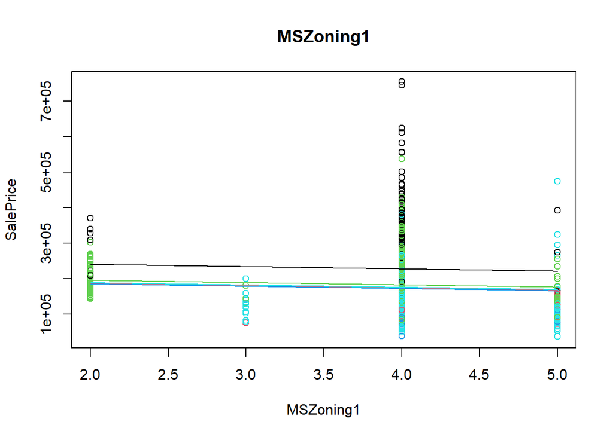

```r
plot(SalePrice ~ MSZoning1, data = train, col = as.factor(BsmtQual), main = 'MSZoning1')

drawit <- function(Fa = 0, Gd = 0, NoBa = 0, TA = 0, i){
  curve(b[1] + b[2]*mean(train$X1stFlrSF) + b[3]*mean(train$X2ndFlrSF) + b[4]*mean(train$OverallQual) + b[5]*mean(train$YearRemodAdd) + b[6]*mean(train$MasVnrArea, na.rm = TRUE) + b[7]*Fa + b[8]*Gd + b[9]*NoBa + b[10]*TA + b[11]*mean(train$BsmtFinSF1) + b[12]*mean(train$BsmtFinSF2) + b[13]*mean(train$GarageArea) + b[14]*mean(train$MSZoning2, na.rm = TRUE) + b[15]*MSZoning1, add = TRUE, xname = 'MSZoning1', col = palette()[i])
}

drawit(0,0,0,0,1)
drawit(1,0,0,0,2)
drawit(0,1,0,0,3)
drawit(0,0,1,0,4)
drawit(0,0,0,1,5)
```

## Validation

The validation below shows the R-squared and adjusted R-squared from the high dimensional regression I did earlier (in ‘The Regression and Interpretation’ tab), and the validation adjusted R-squared of 0.8306 indicates that it is a good model for the data.

```r
set.seed(171)

num_rows <- 1000 #1460 total
keep <- sample(1:nrow(train), num_rows)

mytrain <- train[keep, ] #Use this in the lm(..., data=mytrain) it is like "rbdata"

mytest <- train[-keep, ] #Use this in the predict(..., newdata=mytest) it is like "rbdata2"
```

```r
 mylm <- lm(SalePrice ~ X1stFlrSF + X2ndFlrSF + OverallQual + YearRemodAdd + MasVnrArea + BsmtQual + BsmtFinSF1 + BsmtFinSF2 + GarageArea + MSZoning2 + MSZoning1, data = train)

 yhtrue <- predict(mylm, newdata=mytest, na.rm = TRUE)

  # Compute y-bar
  ybar <- mean(mytest$SalePrice, na.rm = TRUE) #Yi is given by Ynew from the new sample of data

  # Compute SSTO
  SSTO <- sum( (mytest$SalePrice - ybar)^2 )

  # Compute SSE for each model using y - yhat
  SSEt <- sum( (mytest$SalePrice - yhtrue)^2 , na.rm = TRUE)

  # Compute R-squared for each
  rst <- 1 - SSEt/SSTO

  # Compute adjusted R-squared for each
  n <- length(mytest$SalePrice) #sample size
  pt <- length(coef(mylm)) #num. parameters in model
  rsta <- 1 - (n-1)/(n-pt)*SSEt/SSTO


my_output_table2 <- data.frame(Model = "My Model", `Original R2` = summary(mylm)$r.squared, `Orig. Adj. R-squared` = summary(mylm)$adj.r.squared, `Validation R-squared` = rst, `Validation Adj. R^2` = rsta)

colnames(my_output_table2) <- c("Model", "Original $R^2$", "Original Adj. $R^2$", "Validation $R^2$", "Validation Adj. $R^2$")

knitr::kable(my_output_table2, escape=TRUE, digits=4)
```

| Model | Original $R^2$ | Original Adj. $R^2$ | Validation $R^2$ | Validation Adj. $R^2$ |
| --- | --- | --- | --- | --- |
| My Model | 0.7993 | 0.797 | 0.8358 | 0.8306 |